# HW04 Solutions

STATS401 team

## Q1

The answer is $n-m+1$. For the case where $m = 1$, we can see that the formula correctly gives us $\sum_{i = 1}^{n} 1 = n-1+1 = n$.

## Q2

1. These are not necessarily equal. For example, suppose $m < n$. Then $\sum_{i = 1}^{n} x_i = \sum_{i = 1}^{m} x_i + \sum_{i = m+1}^{n} x_i$ and so the two sides are not equal unless $\sum_{i = m+1}^{n} x_i = 0$
2. These are equal. $i$ and $k$ are arbitrary indexing variables.
3. These are not necessarily equal. For example, if $x_i = 1$ for all $i$, and $z_i = 2$ for all $i$, then the two values will be different.
4. These are not necessarily equal. For example, if $x_i = 1$ for all $i = 1, \dots, n$, and $x_i = 2$ for all $i = n+1, \dots, 2n$, then the two values will be different.

## Q3

Because $\bar{x}$ can be treated as a constant we have $\sum_{i = 1}^{n} (x_i - \bar{x}) = \sum_{i = 1}^{n} x_i - \sum_{i = 1}^{n}\bar{x} = \sum_{i = 1}^{n} x_i - n\bar{x}$.

However, $n\bar{x} = n\frac{1}{n}\sum_{i = 1}^{n}x_i = \sum_{i = 1}^{n}x_i$, so the above quantity is zero.

## Q4

$\textbf{1}^\top\textbf{x} = \begin{bmatrix} 1 & 1 & \dots & 1\end{bmatrix}\begin{bmatrix} x_1 \\ x_2 \\ \vdots \\ x_n\end{bmatrix} = x_1 + x_2 + \dots + x_n = \sum_{i = 1}^{n}x_i$

## Q5

First, load the data

```r
mice <- read.csv("https://ionides.github.io/401f18/hw/hw01/femaleMiceWeights.csv")
```

1. Let $x_i, i = 1, 2, \dots, 12$ be the weights for the 12 mice on the high fat diet.

The sample mean is given by $\bar{x} = \sum_{i = 1}^{12}x_i$. The sample standard deviation is given by $s = \sqrt{\frac{1}{11}\sum_{i = 1}^{12}(x_i - \bar{x})^2}$.

To obtain these values in R, we first subset to the high fat diet:

```r
data_hf = mice[mice$Diet == "hf",2]
```

We then use the mean and sd function to obtain the desired values:

```r
sample_mean = mean(data_hf)
sample_sd = sd(data_hf)
sample_mean
```

```
## [1] 26.83417
```

```r
sample_sd
```

```
## [1] 4.097606
```

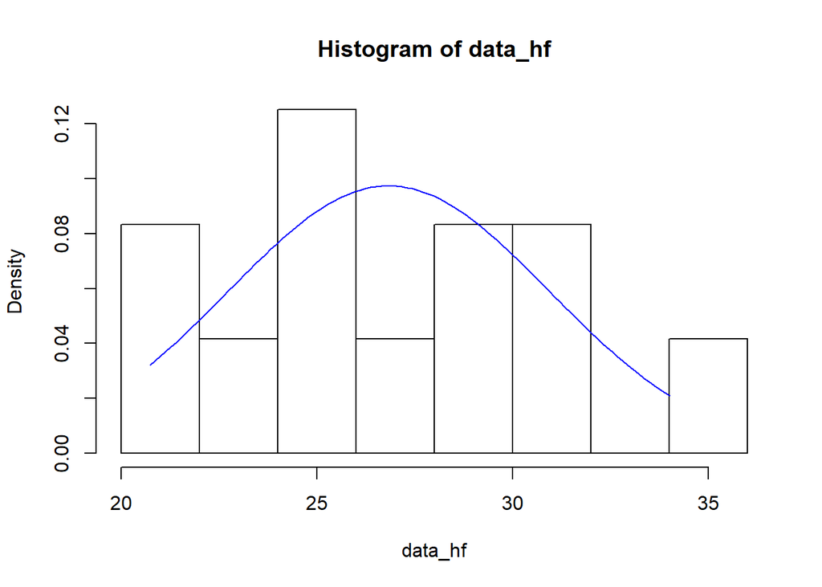

```r
hist(data_hf, freq = FALSE)
normal.x = seq(from = min(data_hf), to = max(data_hf),length = 100)
normal.y = dnorm(normal.x, mean = sample_mean, sd = sample_sd)
lines(normal.x,normal.y,col = "blue")
```

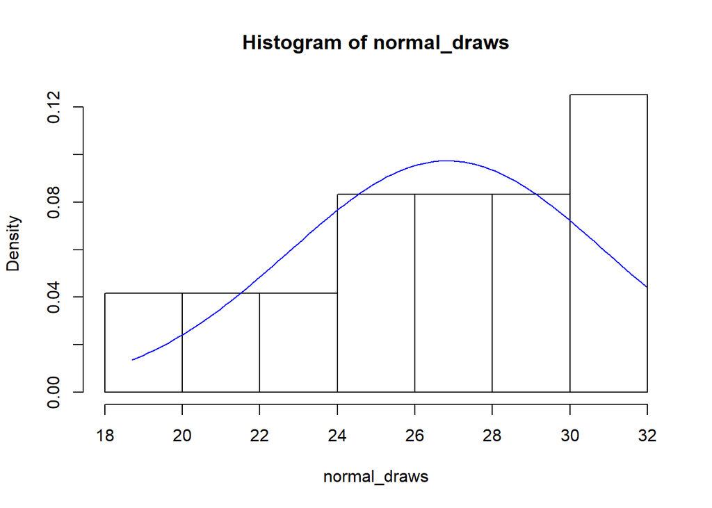

```r
normal_draws = rnorm(12,sample_mean,sample_sd)

hist(normal_draws, freq = FALSE)
normal.x = seq(from = min(normal_draws), to = max(normal_draws),length = 100)
normal.y = dnorm(normal.x, mean = sample_mean, sd = sample_sd)
lines(normal.x,normal.y,col = "blue")
```

```r
1-pnorm(1) + pnorm(-1)
```

```
## [1] 0.3173105
```

Alternatively, we can obtain the same result by symmetry:

```r
2*pnorm(-1)
```

```
## [1] 0.3173105
```

3. We can calculate the amount more than 1 sample standard deviation above or 1 sample standard deviation below the sample mean as follows:

```r
above = sum(data_hf > sample_mean + sample_sd)
below = sum(data_hf < sample_mean - sample_sd)
```

Then we calculate the percentage more than 1 sample standard deviation away from the sample mean:

```r
(above+below)/12
```

```
## [1] 0.3333333
```

This value is fairly close to the value given under a normal approximation.

## Q6

```r
my_t <- function(n){
  rnorm(1) / sqrt(sum(rnorm(n)^2/n))
}
```

(a)-(c)

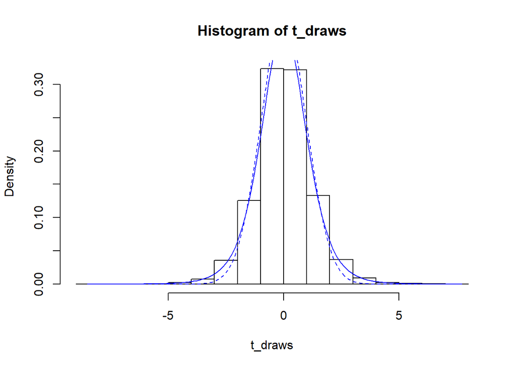

```r
t_draws = replicate(10000,my_t(6))
hist(t_draws, breaks = 15, freq = FALSE)

x = seq(from = min(t_draws), to = max(t_draws),length = 100)
t.y = dt(x, df = 6)
normal.y = dnorm(x, 0, 1)

lines(x,t.y, col = "blue")
lines(x,normal.y, col = "blue",lty = "dashed")
```

Both densities are unimodal and symmetric; however, the t distribution has thicker tails than the normal distribution.

## Q7

```r
my_F <- function(m,n){
   sum(rnorm(m)^2/m) / sum(rnorm(n)^2/n)
}
```

(a)-(b)

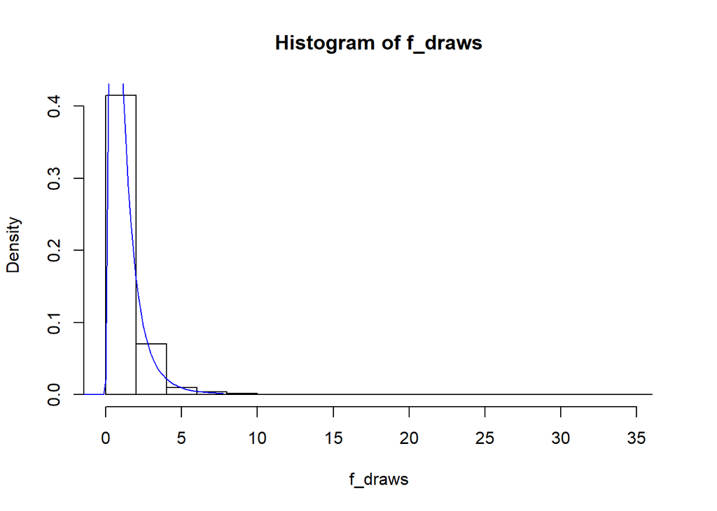

```r
f_draws = replicate(10000,my_F(5,10))
hist(f_draws, breaks = 15, freq = FALSE)

x = seq(from = min(t_draws), to = max(t_draws),length = 100)
f.y = df(x, df1 = 5, df2 = 10)

lines(x,f.y, col = "blue")
```

3. When $m = 1$, we can write Eq 2 as $V = \frac{\sum_{i=1}^{1}Y_i^2/1}{\sum_{j=1}^{n}Z_j^2/n} = \frac{Y_1^2}{\sum_{j=1}^{n}Z_j^2/n}$, where $Y_1, Z_1, \dots, Z_n$ are draws from a standard normal distribution. This corresponds exactly to the square of Eq 1. We can therefore conclude $V$ has the same distribution as $U^2$.